# Allies and Enemies

**This homework is due Sunday April 10, 2016 at 11:59PM EST. When complete, submit your code in an R Markdown file and the knitted HTML via GitHub.**

# Introduction

The United Nations (UN) is an intergovernmental organization founded in 1946 to promote international cooperation. It now represents 193 member states. The General Assembly is the largest body, with a seat for every member of the UN. It discusses topics of international importance such as maintaining peace and security, providing humanitarian aid, and protecting human rights.

We will be analyzing a dataset containing the full history of General Assembly votes by each country to determine what countries vote similarly and which do not. We will also explore how this changes through time.

# Problem 1

We’ll start by loading the United Nations voting data into R and performing some data wrangling. We use data from this paper:

> Voeten, Erik; Strezhnev, Anton; Bailey, Michael, 2009, “United Nations General Assembly Voting Data”, http://hdl.handle.net/1902.1/12379, Harvard Dataverse, V11

In this problem, we will combine information from three sources to create the datasets that we will use to study voting behavior.

### Problem 1A

We have learned how to import text files into R. Here we are going to load a data object that is saved to a file. To get an idea of how this works try the following:

```r
temp_filename <- tempfile() ## creaate tempory file name
temp_object <- 1:5 ## create an R object
save(temp_object, file=temp_filename) ## save the r object to file
rm(temp_object) ## remove object
load(temp_filename) ## load object from file
temp_object ## note that it's back
```

```
## [1] 1 2 3 4 5
```

We usually use the suffix `.RData` or `.rda` for these objects.

The data for this project is stored as an `.RData` file. Go to [this web page](https://dataverse.harvard.edu/dataset.xhtml?persistentId=hdl:1902.1/12379). To get the `.RData` file, click on the Download button for `rawvotingdata13.tab` and choose the `RData format`.

To load the data set into R, use the `load()` function. Define the name of the object as `x` (but do NOT print it out as it has over 1 million rows).

```r
# Had trouble assigning this directly to a variable, so using the default variable
load("rawvotingdata13.RData")
```

### Problem 1B

The first problem to overcome is that if you try to print this object, it will crash your R session – it’s just that big! (1051752 rows). So first wrap it in `tbl_df(x)`, and call it `votes`. After doing this you can erase `x` with `rm(x)`.

```r
library(dplyr)
votes <- tbl_df(x)
```

### Problem 1C

We note that the data is already arranged according to the rules of tidy data. There is one row for each observation and one column for each variable.

Download the `Codebook.pdf` file from [this page](https://dataverse.harvard.edu/dataset.xhtml?persistentId=hdl:1902.1/12379). How would you interpret the vote column? How many of each kind of vote are in this dataset?

```r
# The votes column is a categorical variable showing the voting choice
#1 – Yes
#2 – Abstain
#3 – No
#8 – Absent
#9 – Not a member

# Counts of each type of vote
votes %>% group_by(vote) %>% summarise(count=n())
```

```
## Source: local data frame [5 x 2]
##
##    vote  count
##   (dbl)  (int)
## 1     1 577756
## 2     2  93387
## 3     3  53891
## 4     8  72197
## 5     9 254521
```

Of the five types of votes, which three would provide information about the country’s position on an issue? Which two would not?

Filter out the types of votes that do not provide information about our countries position on an issue from our dataset.

```r
# Keeping votes between 1 and 3 inclusive (yes,no,abstain)
votes <- votes %>% filter(vote %in% seq(1:3))
```

### Problem 1D

According to the codebook, which column represents countries? What type of unique code is used to represent each country?

**Your answer here**: The ccode column contains the COW (Correlates of War(numeric)) country codes.

Create new `country` column that contains country names based on this column. Hint: check out the [countrycode](https://cran.r-project.org/web/packages/countrycode/countrycode.pdf) package.

```r
library(countrycode)
votes <- votes %>% mutate(country=countrycode(ccode,"cown","country.name"))
```

### Problem 1E

Before continuing let’s wrangle the country names a bit. We are renaming countries with long names and renaming Congo to distinguish it from Democratic Republic of Congo. We make use of the powerful remapping function `revalue()` from `plyr` package. You should **not** load `plyr` though as it will create confusion with `dplyr` functions.

```r
library(tidyr)
mapping <- c("United States"="USA",
          "United Kingdom"="UK",
          "Korea, Republic of"="South Korea",
          "Lao People's Democratic Republic"="Laos",
          "Yemen People's Republic"="South Yemen",
          "Saint Vincent and the Grenadines"="Saint Vincent",
          "Congo"="Congo Republic")
votes <- votes %>% mutate(country = plyr::revalue(country, mapping)) %>%
  separate(country, into = c("country", "extra"), sep=",", fill="right")
```

Right now we have information about how every country voted on every resolution. But we do not have any information about the resolutions themselves (e.g. not what their title or topic was, or what date they were voted on). Next, we will bring this data in as well.

This data is provided as `descriptions.csv`. Read it in using the `readr` package and wrangle it as shown below:

```r
library(readr)

url <- "https://raw.githubusercontent.com/datasciencelabs/data/master/un-resolutions-descriptions.csv"
descriptions <- read_csv(url, col_types = list(date = col_date("%m/%d/%y")))
## from warning and looking at csv we see
## line 1483 has an extra "
## it's supposed to be a 0
descriptions[1483,"ec"] <-0

library(lubridate)
y <- year(descriptions$date)
year(descriptions$date) <- ifelse(y > 2030, y - 100, y)
```

Count the number of votes that were taken in each year. Create a line graph of the number of votes per year.

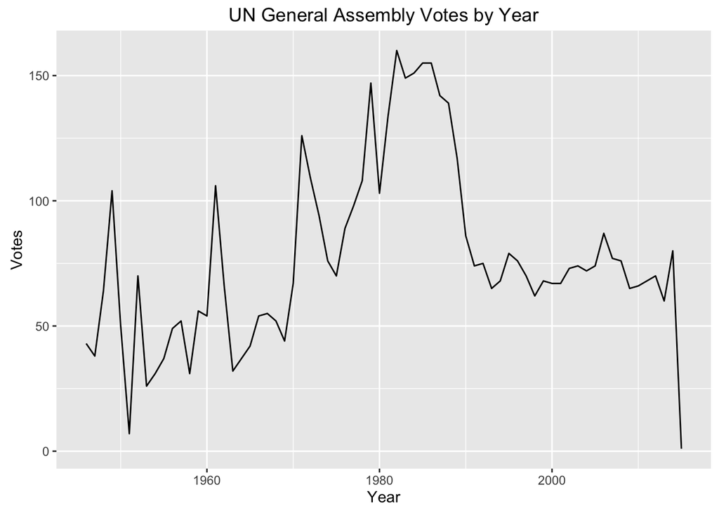

```r
# Summarize votes by year
votes_per_year <- descriptions %>% mutate(year=year(date)) %>% group_by(year) %>% summarise(vpy=n())

# line plot of votes per year
library(ggplot2)
votes_per_year %>% filter(!is.na(year)) %>% ggplot(aes(year,vpy)) + geom_line() + xlab("Year") + ylab("Votes") + ggtitle("UN General Assembly Votes by Year")
```

What year would we want to filter out from the dataset because there was only one vote?

**Your answer here**: 2015

Filter it out now.

```r
votes_per_year <- votes_per_year %>% filter(vpy>1)
```

### Problem 1F

Read the `Codebook.pdf` about this dataset. Who classified certain votes as “important”?

**Your answer here**: U.S. State Department report Voting Practices in the United Nations

What percent of votes in history were categorized as “important”?

```r
# 6.88% of votes were classed as important
paste(round(100*(sum(descriptions$importantvote==1,na.rm=TRUE) / nrow(descriptions)),2),"%")
```

```
## [1] "6.88 %"
```

The most interesting analyses can be done by combining the description and country-voting data.

Join the `description` and country-voting data (`votes`) to create a new data set. Remove the `yes`, `no`, and `abstain` columns from the `description` dataset. These are per-vote summaries that we do not need any more (and could be misleading). The final dataset should be called `votes`, which you will continue to use throughout the homework.

```r
desc <- descriptions %>% select(-c(yes,no,abstain))

votes <- votes %>% left_join(desc,by=c("rcid","session"))
```

# Problem 2

### Problem 2A

Canada and the US have been allies since the UN was created. We can create a matrix of all votes for these two countries using the `spread()` function in `tidyr` package like this:

```r
library(tidyr)
y <- votes %>%
  filter(country %in% c("USA", "Canada")) %>%
  mutate(year = year(date)) %>%
  select(rcid, year, importantvote, country, vote) %>%
  spread(country, vote)
```

We can see how often they have voted together in important votes and not-important votes:

```r
y %>%
    group_by(importantvote) %>%
    summarize(mean(USA==Canada, na.rm=TRUE))
```

```
## Source: local data frame [3 x 2]
##
##   importantvote mean(USA == Canada, na.rm = TRUE)
##           (int)                             (dbl)
## 1             0                         0.5501927
## 2             1                         0.6475410
## 3            NA                         1.0000000
```

Compute the percentage in which the US and Canada voted the same. Calculate this percentage for each year and call it `agreement`. Fit a linear model using `lm()` to predict `agreement` with `year`.

```r
# Removing years with NA
datx <-y %>%
    filter(!is.na(year)) %>%
    group_by(year) %>%
    summarize(agreement=mean(USA==Canada,na.rm=TRUE)*100)

# Basic linear regression
m <- datx %>% lm(agreement ~ year,data=.)


summary(m)
```

```
##
## Call:
## lm(formula = agreement ~ year, data = .)
##
## Residuals:
##     Min      1Q  Median      3Q     Max
## -28.258  -9.726  -4.651   9.205  61.703
##
## Coefficients:
##               Estimate Std. Error t value Pr(>|t|)
## (Intercept) 1282.01301  187.24698   6.847 2.85e-09 ***
## year          -0.61723    0.09453  -6.530 1.04e-08 ***
## ---
## Signif. codes:  0 '***' 0.001 '**' 0.01 '*' 0.05 '.' 0.1 ' ' 1
##
## Residual standard error: 15.9 on 67 degrees of freedom
## Multiple R-squared:  0.3889, Adjusted R-squared:  0.3798
## F-statistic: 42.63 on 1 and 67 DF,  p-value: 1.043e-08
```

What is the trend predicted by the linear model? Is it statistically significant?

**Your answer here**: We are seeing a negative trend of agreement between the US and Canada over time. The trend is highly significant with a p-value <.001.

### Problem 2B

Now, instead of blindly interpreting the regression results, plot the data and use a smoother to estimate a trend. Based on this analysis, how do thes Regan and Clinton administrations compare?

**Hint**: Make sure to pick a window size or span that creates a trend that goes through data.

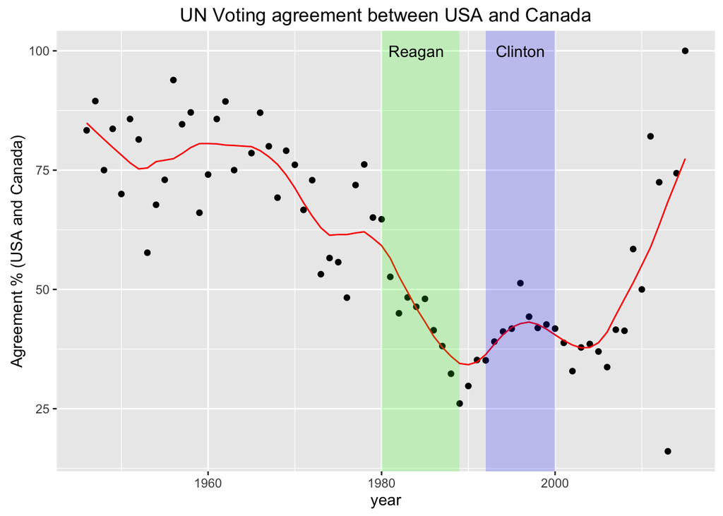

```r
library(broom)
#I feel a span of between .2 and .25 creates the best fit
span <-.2

mod <- loess(agreement~year, degree=1, span = span, data=datx)
loess_fit <- augment(mod)


# Plotting the loess fit and highlighting the data corresponding to Reagan and Clinton administrations
datx %>% ggplot() +
  geom_point(aes(year, agreement)) +
  geom_line(aes(x=year, y=.fitted), data=loess_fit, color="red") +
  annotate("rect", xmin=1992, xmax=2000, ymin=-Inf, ymax=Inf, alpha=.2, fill="blue") +
  annotate("rect", xmin=1980, xmax=1989, ymin=-Inf, ymax=Inf, alpha=.2, fill="green") +
  annotate("text", x=1996,y=100,label="Clinton") +
  annotate("text", x=1984,y=100,label="Reagan") +
  ylab("Agreement % (USA and Canada)") +
  ggtitle("UN Voting agreement between USA and Canada")
```

```r
# We can see quite clearly here that during the Reagan administration, the voting agreement between the USA and Canada worsened significantly. The Clinton administration saw an overall improvement, but it was comparitively small change.

# In numbers, we see a decline of ~39% during the Reagan administration and a ~7% increase during the Clinton administration
datx%>% filter(year %in% c(1980,1989,1992,2000)) %>% mutate(administration=ifelse(year>1990,"Clinton","Reagan")) %>% group_by(administration) %>% summarise(change=last(agreement)-first(agreement))
```

```
## Source: local data frame [2 x 2]
##
##   administration    change
##            (chr)     (dbl)
## 1        Clinton   6.65591
## 2         Reagan -38.61893
```

### Problem 2C

Make the plot above for the agreement through time between the US and the following countries: Israel, UK, Mexico, Cuba, and China. Make two plots: one for important votes to non-important votes.

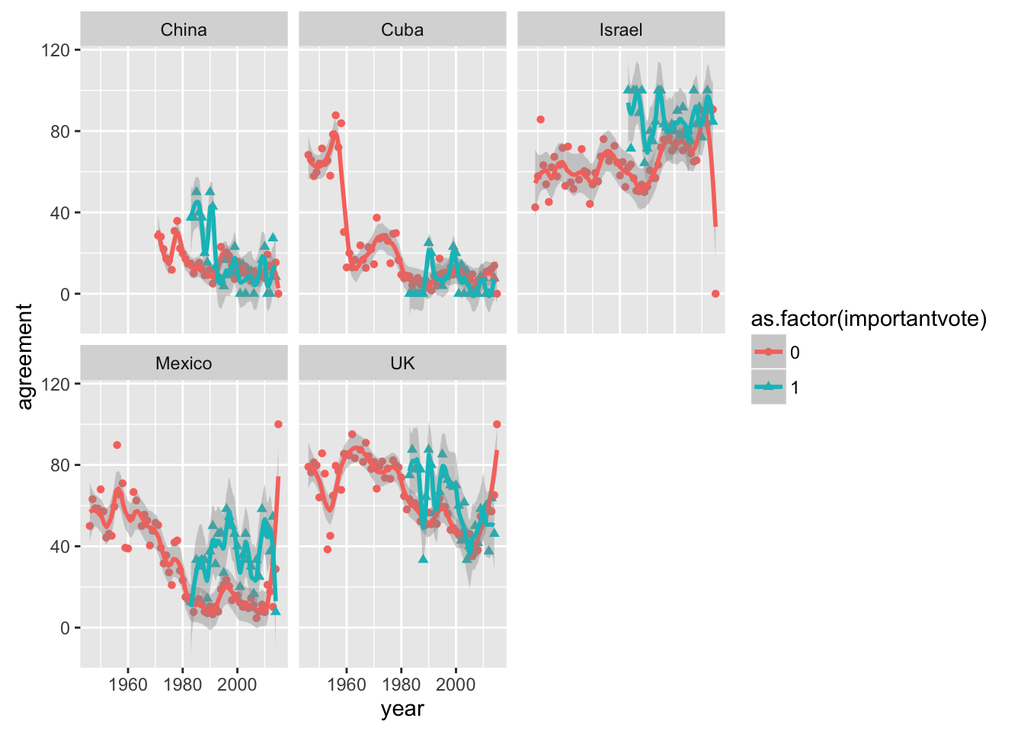

```r
# Select only countries of interest and extract year
country.votes <- votes %>%
  filter(country %in% c("USA", "Israel","Mexico","Cuba","China","UK")) %>%
  mutate(year = year(date)) %>%
  select(rcid, year, importantvote, country, vote)

# Compare US against each of the other countries
usa.votes.compare <- country.votes %>%
  filter(country =="USA") %>%
  mutate(USvote=vote) %>%
  select(-c(country,vote)) %>%
  left_join(country.votes %>%
              select(rcid,country,vote) %>%
              filter(country != "USA"),by="rcid") %>%
  group_by(country, year,importantvote) %>%
  summarize(agreement= mean(USvote==vote, na.rm=TRUE)*100)

# Having a preliminary look through the using ggplot
usa.votes.compare %>%
  ggplot(aes(year, agreement,color=as.factor(importantvote),shape=as.factor(importantvote))) +
  geom_point() +
  stat_smooth(method="loess",span=span) +
  facet_wrap(~country)
```

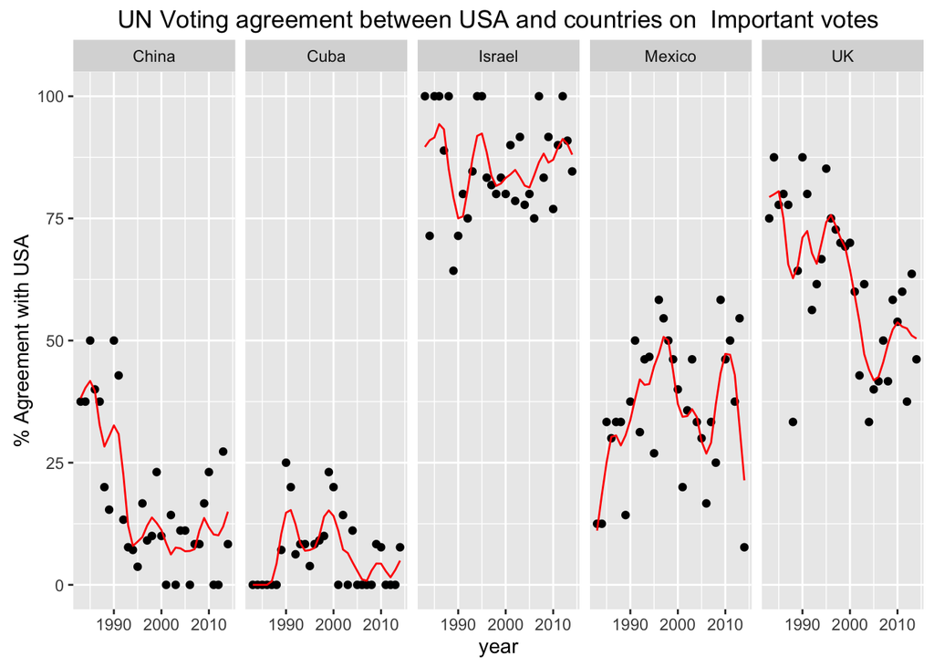

```r
plotVotes <- function(important=TRUE){
  usa.votes.status <- usa.votes.compare %>%
  filter(importantvote==important) %>%
  group_by(country) %>%
  do(augment(loess(agreement~year, degree=1, span = span, data=.),data=.))

  usa.votes.status %>% ggplot() +
  geom_point(aes(year, agreement)) +
  geom_line(aes(x=year, y=.fitted), color="red") +
  facet_grid(~country) +
  ylab("% Agreement with USA") +
  ggtitle(paste("UN Voting agreement between USA and countries on",
                ifelse(important,"","Non -"),
                "Important votes"))
}


# Checking agreement between US and each country votes on important issues
plotVotes()
```

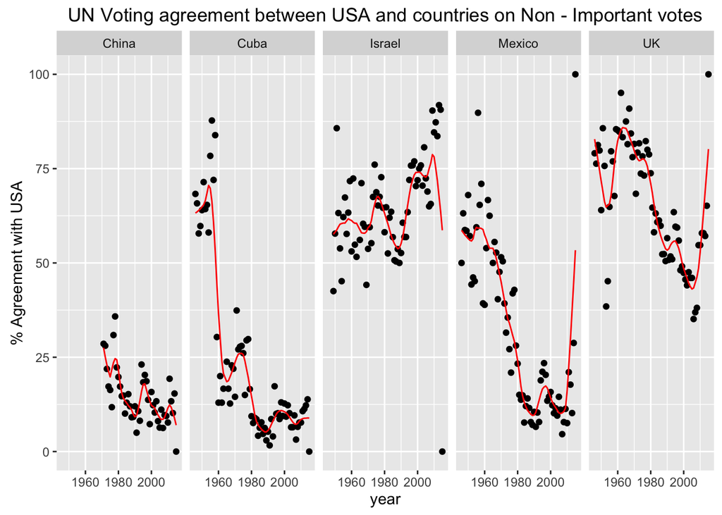

```r
# Repeat analysis for non-important countries
plotVotes(important = FALSE)
```

Describe the observed patterns.

**Your answer here**: On important issues, the US voting agreement with Israel is very strong. In many years, the US and Israel agree on every vote. In contrast, the US and Cuba disagree strongly. The disagreement with China is less strong, but every year, there is at most a 50% agreement record. The voting pattern with Mexico and the UK is less extreme, with Mexico mostly disagreeing and the UK mostly agreeing with the US.

For non-important issues, the voting pattern is more spread for each country except China.

# Problem 3

In this problem, we will focus only on important votes. To get a better idea of who votes together we can compute a distance between each country. We will focus on countries that voted more than 95% of time in the 368 votes

```r
countries <- votes %>%
                filter(importantvote==1) %>%
                group_by(country) %>%
                summarize(p=n()/368) %>%
                filter(p>=0.95) %>%
                .$country
```

We can create a matrix with all the votes using the `spread()` function:

```r
tmp <- votes %>%
    filter(country %in% countries & year(date) >= 1980 & importantvote == 1) %>%
    select(rcid, country, vote) %>%
    spread(country, vote)

X <- as.matrix(tmp[,-1])
rownames(X) <- tmp$rcid
```

### Problem 3A

Create a distance matrix between each country. Call this matrix `d`.

**Hint**: Use the `dist()` function, but note that `X` has countries in the columns and `dist()` computes distances between rows. Look at the `dist` help file for more infomration. You can use the default `method = "Euclidean"` in the `dist()` function. You can switch rows to columns using the `t()` (transpose) function. Finally, once you create the distance matrix `d` you can visualize it using `heatmap()` or `hclust()`.

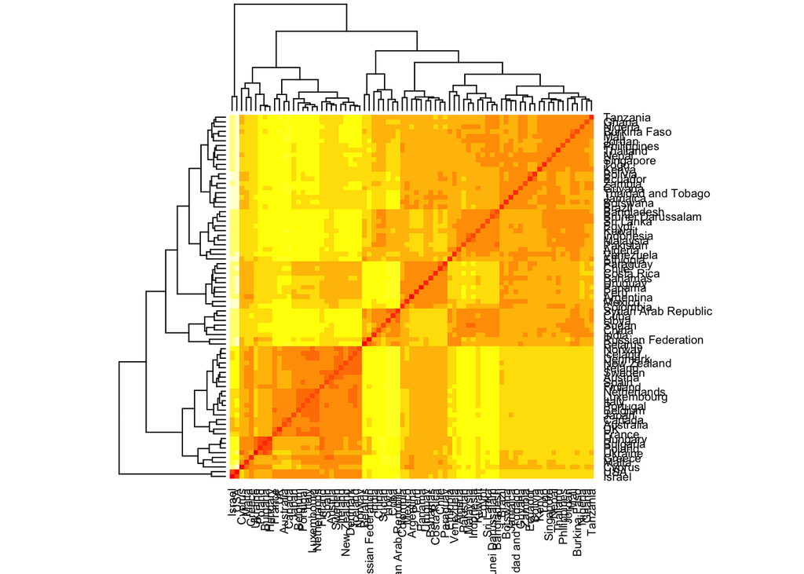

```r
#Transpose
t <- t(X)

#Calculate distance between countries
d = dist(t)

heatmap(as.matrix(d))
```

```r
#Placing the distance into a matrix for interogating as the farthest is not clear from the dendogram
m <- as.matrix(d)


# USA is in row 75
which(m==max(m[75,]),arr.ind=T)
```

```
##      row col
## USA   75  20
## Cuba  20  75
```

What country is closest to US? Which is furthest?

**Your answer here**: Closest is Israel, furthest is Cuba

### Problem 3B

Given how close some countries are and how far others are to US in voting, we should be able to predict how the US will vote based on others. Let’s try to implement a machine learning algorithm to do this.

Use the `votes` data set to create a new dataset with seven columns. One column will represent the USA vote as the outcome (call it `y`) and the last six columns will be the vote from the six countries examined above in Problem 2 (include Canada), which will be used a predictors in our machine learning algorithm. Only consider the important votes. In the column for the USA vote column (`y`), remove the `Abstain` votes and only consider the `Yes` and `No` votes from the USA. Tranform the USA vote column (`y`) to contain only 0s and 1s where 0 = `No` vote and 1 = `Yes` vote.

```r
# Keep only important votes and countries of interest.
# Keeping variables of interest
countries.votes <- votes %>%
  filter(importantvote==1 & country %in% c("USA", "Israel","Mexico","Cuba","China","UK")) %>%
  select(c(rcid,vote,country))

# Keeping only US yes or no votes.
# Renaming the US votes to y and joining it with the other country votes
# Transposing the countries so there is one record per voting session
usa.votes.agreement <- countries.votes %>%
  filter(country =="USA" & vote %in% c(1,3)) %>%
  mutate(y=as.integer(vote==1)) %>%
  select(-c(country,vote)) %>%
  left_join(countries.votes %>%
              filter(country != "USA"),by="rcid") %>%
  spread(country, vote) %>%
  select(-rcid) #dropping rcid as its not needed anymore

# Filter out any rows with incomplete (NA) data as this causes problems in the knn model
usa.non.null.votes <- usa.votes.agreement[rowSums(is.na(usa.votes.agreement  ))==0,]
```

Use the `caret` R package to split the data into a training set with 80% of data and a test set with the remaing 20%. Then use `glm()` to build a model. What is the accuracy?

```r
library(caret)
set.seed(1)
# Splitting the data 80/20 for training and testing respectively
inTrain <- createDataPartition(y = usa.non.null.votes$y,
                               p=0.8)
train_set <- slice(usa.non.null.votes, inTrain$Resample1)
test_set <- slice(usa.non.null.votes, -inTrain$Resample1)

# Fitting the GLM based only on the countries voting patterns
glm_fit <- glm(y~.,data=train_set)


f_hat <- round(predict(glm_fit, newdata = test_set,
                 type = "response"))

tab <- table(pred=f_hat, truth=test_set$y)
confusionMatrix(tab)$tab
```

```
##     truth
## pred  0  1
##    0 39  0
##    1  2 24
```

```r
confusionMatrix(tab)$overall["Accuracy"]
```

```
##  Accuracy
## 0.9692308
```

```r
# The accuracy is 97%
```

### Problem 3C

We see that obtain a very high accuracy, but note that this is a random variable due to the random split of our data. Try 10 new random splits and report on how much our accuracy changes.

```r
# Placing previous code into a function

runtestGLM <- function(indata=usa.non.null.votes) {
  inTrain <- createDataPartition(y = indata$y,
                               p=0.8)
  train_set <- slice(indata, inTrain$Resample1)
  test_set <- slice(indata, -inTrain$Resample1)

  # Fitting the GLM based only on the countries voting patterns
  glm_fit <- glm(y~.,data=train_set)


  f_hat <- round(predict(glm_fit, newdata = test_set,
                 type = "response"))

   tab <- table(pred=f_hat, truth=test_set$y)

   return(confusionMatrix(tab)$overall["Accuracy"])
}

set.seed(1)
# Re-running 10 times
accuracy <- replicate(10,runtestGLM())

# Checking spread of results
summary(accuracy)
```

```
##    Min. 1st Qu.  Median    Mean 3rd Qu.    Max.
##  0.8615  0.9385  0.9538  0.9446  0.9692  0.9846
```

```r
sd(accuracy)/sqrt(length(accuracy))
```

```
## [1] 0.01151279
```

```r
# We are not seeing that our model is accurate between 86 over 98% of the time on our limited sample with an se of .012
```

### Problem 3D

Compare your `glm()` model to a `knn()`. Use the `train()` function to run 10 cross validations with leaving out 80% of the data. Plot your results.

```r
runtestKNN <- function(indata=usa.non.null.votes) {
  inTrain <- createDataPartition(y = indata$y,
                               p=0.8)
  train_set <- slice(indata, inTrain$Resample1)
  test_set <- slice(indata, -inTrain$Resample1)
  knn_fit <- knn3(y~.,data = train_set)
  f_hat <- round(predict(knn_fit, newdata = test_set)[,2])

  tab <- table(pred=f_hat, truth=test_set$y)
  return(confusionMatrix(tab)$overall["Accuracy"])
}


set.seed(1)
# Re-running 10 times using default of k=5
accuracy <- replicate(10,runtestKNN())

# Checking spread of results
summary(accuracy)
```

```
##    Min. 1st Qu.  Median    Mean 3rd Qu.    Max.
##  0.9077  0.9269  0.9538  0.9446  0.9654  0.9692
```

```r
sd(accuracy)/sqrt(length(accuracy))
```

```
## [1] 0.007675195
```

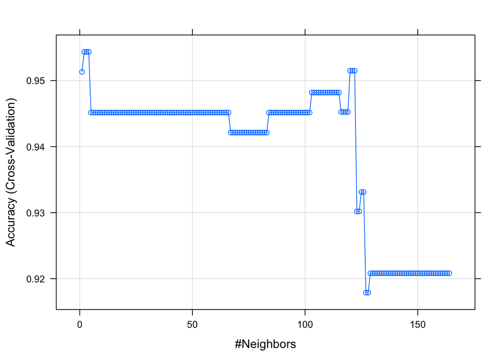

```r
# Over the same training data we see a better accuracy than we observed in the glm. Even though our mean score matched what was observed in GLM, our se is much smaller at .007

set.seed(1)
# Create dataset splits for training and testing

# train with 20% of data, 10 splits
control <- trainControl(method='cv', number=10, p=.2)

dat <- usa.non.null.votes %>% mutate(y=as.factor(y))

res <- train(y ~ .,
             data = dat,
             method = "knn",
             trControl = control,
             tuneLength = 1, # How fine a mesh to go on grid
             tuneGrid=data.frame(k=seq(1,164,1)),
             metric="Accuracy")
plot(res)
```

```r
#res

#Based on the final model k=4 was used
#Without using train, just testing to see if the prediction is similar
set.seed(1)

inTrain <- createDataPartition(y = dat$y,
                               p=0.8)
train_set <- slice(dat, inTrain$Resample1)
test_set <- slice(dat, -inTrain$Resample1)

fit <- knn3(y~., data=dat, k=4)
pred <- predict(fit, newdata = test_set,type="class")

tabx <- table(pred, test_set$y)
confusionMatrix(tabx)
```

```
## Confusion Matrix and Statistics
##
##
## pred  0  1
##    0 35  0
##    1  2 28
##
##                Accuracy : 0.9692
##                  95% CI : (0.8932, 0.9963)
##     No Information Rate : 0.5692
##     P-Value [Acc > NIR] : 1.54e-13
##
##                   Kappa : 0.9378
##  Mcnemar's Test P-Value : 0.4795
##
##             Sensitivity : 0.9459
##             Specificity : 1.0000
##          Pos Pred Value : 1.0000
##          Neg Pred Value : 0.9333
##              Prevalence : 0.5692
##          Detection Rate : 0.5385
##    Detection Prevalence : 0.5385
##       Balanced Accuracy : 0.9730
##
##        'Positive' Class : 0
##
```

How many nearest neighbors should we use?